# Marketing Strategy Documentation Guide

Mission: Can the FAPRI baseline outlook projections be used as a tool for making marketing decisions and managing risk?

### Data

# Futures Pricing Data:

*[Source](https://www.trackntrade.com/futures/eod/): Track n’ Trade EOD Futures*

To get futures pricing data we use the Track n’ Trade EOD Futures program. For each contract month available, we download the price data and use the “close” price from each day accordingly.

# FAPRI Baseline Data:

*[Source](https://www.fapri.missouri.edu/publications/outlook/): FAPRI-MU Baseline Outlook (March and August)*

Each March, FAPRI (University of Missouri Food and Agricultural Policy Research Institute) publishes an agricultural economic baseline, projecting possible market outcomes for the next 10 years based on stochastic analysis. Relevant to our grain marketing strategy is the corn crop price projections. The marketing strategies that follow are centered on FAPRI’s official projected price, the stochastic average, and use the 70th, 80th, 90th, and 95th percentiles as above average price points.

FAPRI’s baseline values are what all of the models function on with the exception of seasonal sales. From March through August we use the March baselines. From September through February we use the August baseline update.

# Basis Data:

*[Source](https://www.ers.usda.gov/data-products/season-average-price-forecasts/): USDA ERS Season-Average Price Forecasts*

The basis is an integral part to calculating accurate adjustments for the baselines we are provided with from FAPRI. The basis is the difference between the current cash price and the current futures price. The basis is calculated by using the average monthly basis and multiplying it by the monthly marketing weights for each month. These values are then added across a USDA marketing year (September- August) to get the the basis for a given year.

# USDA Averages:

*[Source](https://www.ers.usda.gov/data-products/season-average-price-forecasts/): USDA ERS Season-Average Price Forecasts*

The USDA average is simply used as a comparison tool for our strategies. The basis-adjusted average is calculated by using the annual price received by producers and subtracting the basis found above for each respective year accordingly.

# Codebase:

*[Source](https://github.com/fapri/main-model): GitHub*

The entirety of our models and data is stored on GitHub for ease of collaboration between developers. The code can be viewed and accessed using the link above.

### Model Constraints

# Marketing Year:

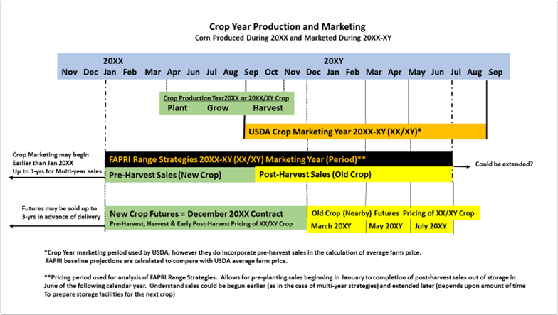

# Storage:

Storage is calculated the same across strategies and crops. Storage costs differ based on if on-farm or commercial storage is being utilized. On-farm storage should always be filled first because it is cheaper, and we assume farmers to have 50% of their crop production available in storage space. Storage is not utilized until post-harvest November. So, if we are in post-harvest November and have already sold 50% of our crop, the remaining crop will be put into on-farm storage. In contrast, if we have 70% of crop left, 20% will be put into commercial storage and the remaining 50% will be put into on-farm storage. In some cases where both on-farm and commercial storage is utilized, we need to split specific sales so that some of the crop from the sale goes into on-farm storage and some of the crop goes into commercial storage. Below is the formulas and constants for each storage type.

**On Farm:**  
$(Price×(1+\frac{interest}{12})^{months\ after\ Oct.}+Total\ cost\ of\ bin\ storage, 1st\ month+ \\ \qquad Total\ cost\ of\ bin\ storage,2nd\ month\ forward×(months\ after\ Oct.-1))-Price$  
**Commercial:**  
$(Price×(1+\frac{interest}{12})^{months\ after\ Oct.}+ \\ \qquad Max(Monthly\ commercial\ storage\ cost×months\ after\ Oct., \\ \qquad Three\ month\ minimum\ storage\ charge))-Price$  
**Constants:**

$Interest = 0.055$  
$Total\ cost\ of\ bin\ storage,1st\ month = 0.2469625$  
$Total\ cost\ of\ bin\ storage,2nd\ month\ forard = 0.0032$  
$Monthly\ commerical\ storage\ cost = 0.05$  
$Three\ month\ minimum\ storage\ charge = 0.15$

### Strategies

# Price Objective:

Our Price Objective strategy can be defined as our upside strategy. FAPRI’s baseline ranges are used for this strategy. As prices trend higher, sales are triggered when a price hits or goes up through a higher baseline. For example, if the market was at the 90th percentile but then moved through the 95th percentile, a sale would be triggered. In general, Price Objective sales are made at 10%. It is important to note that just because a sale is triggered does not mean it will be actualized.

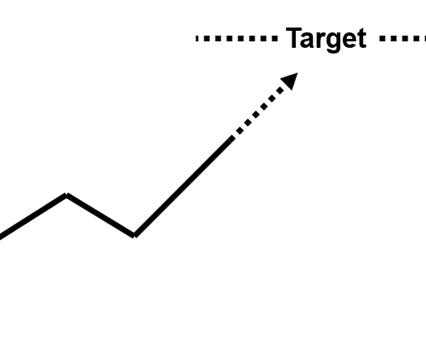

# Trailing Stop:

Our Trailing Stop strategy can be defined as our downside strategy. FAPRI’s baseline ranges are used for this strategy. As prices trend higher, sales are triggered when a price falls of goes down through a lower baseline. For example, if the market was at the 90th percentile but then moved through the 80th percentile, a sale would be triggered. Because of the way this strategy is defined, the highest price will never be captured. In general, Trailing Stop sales are made at 10%. It is important to note that just because a sale is triggered does not mean it will be actualized.

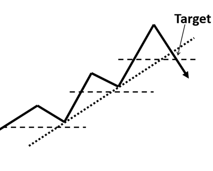

# Seasonal Sales:

It is common knowledge that commodity markets tend to have seasonal trends. Prices rise in the spring, when supplies get tighter, and decline in the fall. Because of these historical trends, we assume that prices will generally be highest in March and June of each crop year for corn, and May and July for soybeans. In this strategy, seasonal sales are made on the 10th and 20th of March and June (May and July for soybeans) and no other types of sales are made. Seasonal sales will always be made at 12.5% of crop production. This is because there are 8 seasonal sale opportunities in each marketing year, and we sell an equal share of crop for each one.

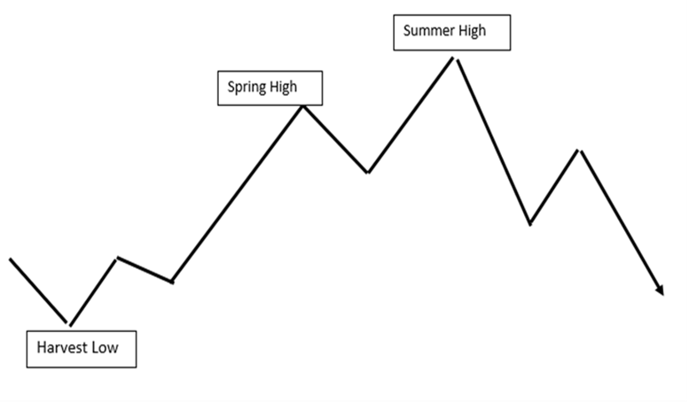

# Multi-Year Sales:

Multi-Year sales attempt to take advantage of unusually high prices. These sales are only triggered by the All Time High Trailing Stop or the 5% Drop from the Ten-Day High, and sales are made on the December contracts for 3 consecutive years. When multi-year sales are being made, up to 60% of crop can be sold in the pre-harvest, 10% higher than usual. Additionally, if in the current year 60% of pre-harvest crop has been sold, but in the next two crop years only 20% has been sold, multi-year sales can still be made for the next two crop years, even though the sale would not be actualized in the current crop year.

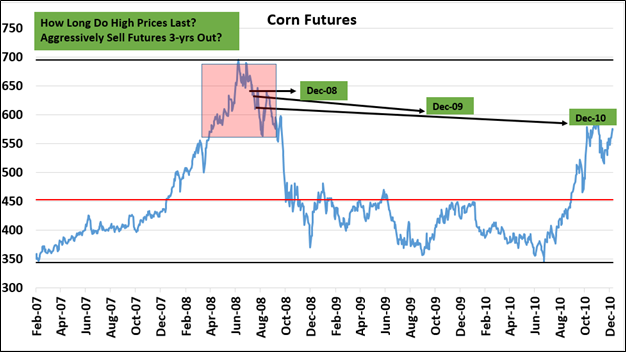

### Actualization

# Actualization:

In our price objective and trailing stop strategies, not all sales that are triggered are actualized. In other words, we don’t make a sale each time a price triggers a trailing stop or price objective sale. We have a set of rules that help us decide which sales are actualized as follows:

- No sales can be made within 7 days of the last sale. If a sale was made on a Tuesday, another sale cannot be made until the following Tuesday. If a sale was made on the 5th, another sale could not be made until the 12th. You do not need to wait until the 8th day to make a sale.
  - The exception to this rule is with the End of the Year Trailing Stop. Since we are trying to sell out, we can make sales multiple days in a row if necessary.
- Only up to 50% of crop can be sold in the pre-harvest. This should not be confused as a quota we need to reach. We can sell less than 50%, but never more than. In the post-harvest we sell out our remaining crop. In multi-year, this percentage increase to 60%.
- During some intervals we limit sales based on if a sale has already been actualized in that percentile. The diagram below shows the timeline for our marketing year and when sales are limited, unlimited, or just not allowed. During the limited times, we only limit price objective and trailing stop sales. Only one sale can be actualized per percentile. For example, if we are in a limited interval for the price objective strategy and have already actualized a 70th percentile sale, if another 70th percentile sale is triggered later in the interval it would not be actualized due to the fact that we already have a 70th percentile sale.

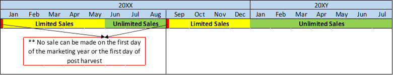

- Seasonal Sales are not to be made when the market is at or above the 70th percentile.
- On every first day of March and September, when there is a baseline change, the previous baseline and percentiles should be used to determine which percentile the futures market price is at for that day. Without this rule, it would be possible for a sale to be made without the price changing. Additionally, the September futures market price on the last day of August must be considered when determining which percentile the previous day’s future market price was at on the first day of September. In other words, on the first day of September, refer to the previous baseline and percentiles to determine the percentile for both the current day and the previous day, but look at the September futures market price on the previous day.

### Alternative Strategies

# Alternative Strategies:

Sometimes our price objective and trailing stop strategies can be bolstered by other strategies in order to gain higher prices or sell out crop at the end of the year. Our alternative strategies are detailed below:

- **Five Percent Drop from the Ten Day High (5%DFTDH)**: Though rare, the futures market will sometimes rise above the 95th percentile. Since there is no chance a PO or TS sale could be made in this situation but obvious reasons to sale at these prices, the 5% DFTDH strategy is employed. This strategy is self-explanatory. When the market is above the 95th percentile and is at a price that is equal to or less than 95% of the highest price over the previous ten days, a sale is triggered.
- **All-Time High Trailing Stop (ATHTS)**: When prices are at or near an all-time high, it is prudent to make as many strategic sales as possible. The ATHTS strategy is a way to make these sales, regardless of the percentile the market is at. When the market is within one dollar of the all-time high, a 10% sale will be made if the market drops 5% from the ten-day high. This strategy is quite similar to the 5% DFTDH strategy but is conditioned on the market being within $1 of the all-time high and not on the market being above the 95th percentile.
- **End of Year Trailing Stop (EYTS)**: This is our “last resort” strategy. If crop remains in Post-Harvest June and we are not below the 70th percentile, we utilize EYTS. If we are using a Price Objective strategy, these PO sales will made as usual (at 10% of crop). But, if the market passes down through a percentile, we make a sale relative to the remaining crop. For example, if we are in Post-Harvest June, have 40% of our crop remaining, and are at the 80th percentile, we would sell 20% of our crop when the market passes down through the 80th percentile and the final 20% when it passes through the 70th percentile. This strategy ensures that all crop will be cleared by the end of the crop year.
- **Seasonal Sales**: Like the seasonal sale strategy, this alternative strategy used in conjunction with the price objective or trailing stop strategy aims to take advantage of historical times of high prices. This strategy is only considered beginning in post-harvest March for corn or post-harvest May for soybeans. It is also conditioned on the price being below the 70th percentile. Seasonal sale dates for corn are March 10th and 20th and June 10th and 20th. The soybean dates are May 10th and 20th and July 10th and 20th. Sales must be made at 10% or more. To determine the percent to be sold, take the percent of crop remaining and divide it by the number of seasonal sales days left for the marketing year. By this, the first seasonal sale date must have at least 40% of crop left, the second must have 30% etc. For example, for corn, if we are on March 10th and have 30% remaining, a seasonal sale would not be made. If we were on June 10th and we had 30% of crop remaining we would make a sale for 15%. This is because there are two seasonal sale date remaining, and half of 30% is 15%.
- **Alternative Baselines (1%)**: In the trailing stop strategy, our goal is to sell when the upward trend turns into a downward trend. We want to avoid selling around minor fluctuations in the market, or when the prices are increasing. To combat selling too soon, the alternative baselines strategy was created to be used in conjunction with trailing stop only. In this strategy, new baselines are calculated at a 1% drop from the original baseline. Trailing stop sales are then triggered based on these percentiles, rather than the original FAPRI baselines. So when the price fall from one of the new percentiles, to the one below it a sale is triggered. For example if yesterday the market was at the 89th percentile and today the market fell to the 79th percentile, a sale would be triggered. It should be noted that all other strategies are still triggered using the original FAPRI baselines.
- **Price Objective/Trailing Stop Special**: On the days were the baselines change, we needed to develop a strategy to ensure that sales were not being made due to a shift in the new baselines. The resulting strategy is such that, on the first day of new baselines, we use the previous day’s baselines to determine if a sale should be made or not. On the second day of the new baselines, we shift to the new baselines since we now have a previous day’s price and accurate percentile to make decisions from. This strategy is used only on the first day of March for the pre-harvest and the post-harvest. We do not need to consider the August update since we are already not able to make a sale on the first day of September.